# BAYESIAN PROJECT

Ana Mendoza and Marali Benitez

2025-04-08

### Introduction

As autism detection techniques advance, different countries have different approaches as to how they study and treat autism. Our purpose in this project is to determine the prevalence rate of autism in different countries. By knowing the true prevalence of autism in a country, that country may be able to allocate resources in necessary locations to help support those with autism, or, if rates in certain countries are inconsistent, it may suggest that autism detection methods may need to be improved or be made more widespread or accessible.

### The Data Set

The data set we will be using is the Autism Prevalence Studies data set collected by the U.S. Department of Health and Human Services and made accessible by Marilia Prata through Kaggle, and can be accessed through the following link: https://www.kaggle.com/datasets/mpwolke/cusersmarildownloadscsv-1csv. It contains information from various peer-reviewed autism prevalence studies conducted around the world. The requirements for a study being included in this compilation were that the study was conducted in English, that it produced at least one autism prevalence estimate, and that the study was population based within a defined geographic area. The way the data was collected varies from study to study, but the most common methods include in-person,mailed, or online surveys, and collecting health, government, or educational records. In order to collect all of this data, a PubMed search was conducted to identify studies published at any time through September 2020 using the search terms: autism (title/abstract) OR autistic (title/abstract) AND prevalence (title/abstract) (Prata, 2023). The data set includes studies from 44 countries, and out of the 26 variables included in the data set, we decibed that the variables we will be focusing on and using in our calculations are the country where the study took place, the sample size of the study, the number of cases of autism found in the study, and the autism prevalence rate found in the study. We will also limit ourselves to studies published from the year 2000 onward.

#### Load and clean the dataset

```r
library(tidyverse)
```

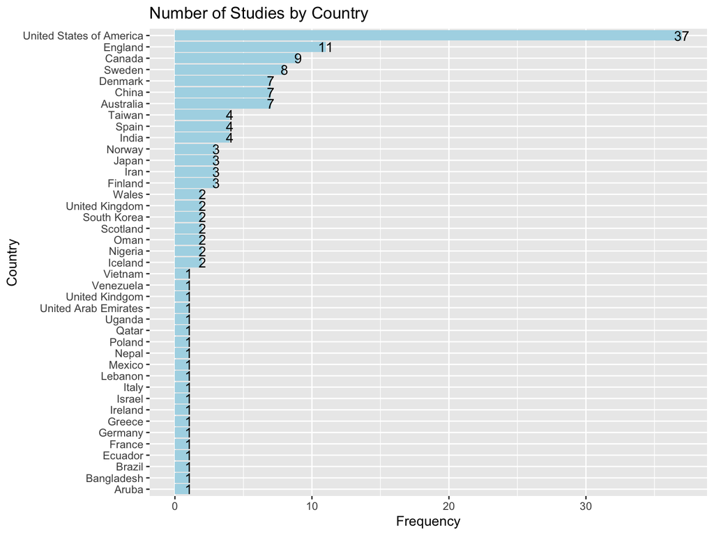

```r
library(ggplot2)
library(bayesrules)
library(rjags)
library(coda)
df <- read.csv("Autism Studies Dataset.csv")

df_clean <- df[!is.na(df$Sample.Size) & !is.na(df$Number.of.Cases), ]

df_clean$y <- df_clean$Number.of.Cases
df_clean$n <- df_clean$Sample.Size
df_clean <- df_clean %>% mutate(Proportion = y/n)

#changing name of some countries
df_clean$Country <- recode(df_clean$Country, USA = "United States of America")
df_clean$Country <- recode(df_clean$Country, "Basque Country, Spain" = "Spain")
df_clean$Country <- recode(df_clean$Country, "Caribbean" = "Aruba")

#limiting dataset to 2000 and onward
df_clean <- df_clean %>% filter(Year.Published>=2000)
df_clean$country_factor <- fct_reorder(df_clean$Country, df_clean$Proportion, .fun = 'mean')
df_clean$country_index <- as.numeric(df_clean$country_factor)

#only selecting necessary variables from dataset
df_clean <- df_clean %>% select(Country, y,n, Proportion, country_factor, country_index)
ggplot(df_clean, aes(x = reorder(Country, Country, function(x) length(x)))) + geom_bar(fill = "lightblue") + geom_text(stat='count',aes(label=..count..)) + coord_flip() + ggtitle("Number of Studies by Country") + ylab("Frequency") + xlab("Country")
```

After cleaning and filtering the data for studies published after 2000, we are left with 144 studies from 41 countries. Most of these studies come from the United States, with England and Canada following in frequency. All 144 studies in our clean data set will be used to try and calculate the autism prevalence rate in each respective country. We will be using JAGS and a hierarchical Beta-Binomial model for our calculations.

### Prepare data for jags

```r
# data for JAGS
y <-  as.integer(df_clean$y) #number of cases
n <- as.integer(df_clean$n) #number of samples
x <- length(y)
n_groups <-  length(unique(df_clean$Country))
country_index <- df_clean$country_index
```

```r
library(rjags)


model_string <- "model{

  # Likelihood
  for (i in 1:x){
    y[i] ~ dbinom(theta[country_index[i]], n[i])
  }

  # Prior
  for (j in 1:n_groups){
    theta[j] ~ dbeta(mu * kappa, (1 - mu) * kappa)
  }


  # Hyperprior, phi=(mu, kappa)
  #uninformative prior for mu and kappa
  mu ~ dbeta(1, 1)
  kappa ~ dgamma(1, 0.1)
}"

data_list <- list(y=y, n=n, n_groups = n_groups, x=x, country_index = country_index)
jags_model <- jags.model(textConnection(model_string), data = data_list, n.chains = 5)
update(jags_model, 1000)  # Burn-in
samples <- coda.samples(jags_model, variable.names = c("theta", "mu", "kappa"), n.iter = 5000)
```

### Diagnostics for MCMC Simulation

```r
source("DBDA2E-utilities.R")
```

[figure not shown]

```r
#diagMCMC(samples, saveName = "diagMCMCproject",saveType = "jpg")
#DbdaAcfPlot(samples)
#DbdaDensPlot(samples)
```

### Posterior densities of hyperparameters

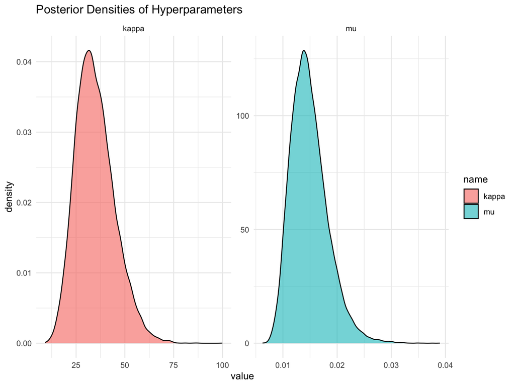

```r
# Convert to data.frame
posterior_df <- as.data.frame(do.call(rbind, samples))


posterior_df %>%
 select(kappa, mu) %>%
 pivot_longer(everything()) %>%
 ggplot(aes(x = value, fill = name)) +
 geom_density(alpha = 0.6) +
 facet_wrap(~name, scales = "free") +
 labs(title = "Posterior Densities of Hyperparameters") +
 theme_minimal()
```

Above are the posterior densities of our hyper parameters kappa and mu. Kappa seems to be centered around 30 and Mu seems to be centered around .014.

# Posterior estimate of Theta + 95% Confidence Interval by Country

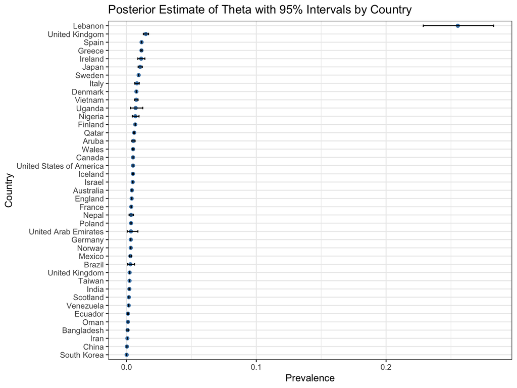

```r
# Extract country names
countries <- levels(df_clean$country_factor)

theta_means <- posterior_df %>%
 select(starts_with("theta[")) %>%
 summarise(across(everything(), list(mean = mean, lower = ~quantile(.x, 0.025), upper = ~quantile(.x, 0.975)))) %>%
 pivot_longer(everything(), names_to = c("param", ".value"), names_pattern = "theta\\[(\\d+)\\]_(.*)") %>%
 mutate(Country = countries[as.integer(param)])

# Plot: Artist posterior mean + 95% CI
ggplot(theta_means, aes(x = mean, y = fct_reorder(Country, mean))) +
 geom_point(color = "steelblue") +
 geom_errorbarh(aes(xmin = lower, xmax = upper), height = 0.3) +
 labs(title = "Posterior Estimate of Theta with 95% Intervals by Country", x = "Prevalence", y = "Country") +
 theme_bw()
```

According to our confidence intervals above, most countries mean autism prevalence are under 1%, with a very small 95% posterior credible interval, with the exception of Lebanon, which has a 95% posterior credible interval of (.229,.283), which is unusually high. The only study included from Lebanon had a sample size of 998 people with 263 of them having ASD, so we can see that the data from that study heavily influenced the posterior.

### Mapping the posterior estimates

```r
library(rnaturalearth)
library(rnaturalearthdata)
```

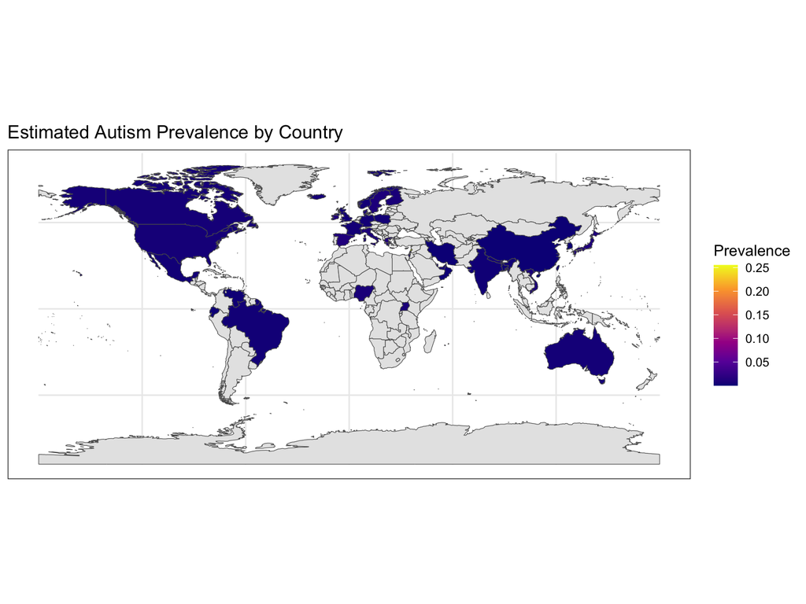

```r
world <- ne_countries(scale = "medium", returnclass = "sf")

world_map <- left_join(world, theta_means, by = c("name" = "Country"))

ggplot(data = world_map) +
  geom_sf(aes(fill = mean)) +
  scale_fill_viridis_c(option = "plasma", na.value = "grey90") +
  labs(title = "Estimated Autism Prevalence by Country",
       fill = "Prevalence") +
  theme_bw()
```

### Conclusions

Our results for the prevalence rate of ASD falls relatively close to the World Health Organization’s estimate for the worldwide autism rate, which is 1 in 100 people (or about 1%) (World Health Organization, 2023).

In order to improve our calculations in the future, inclusion of more recent studies and more data from underrepresented countries would be helpful. Despite the possible limitations of our research, our results overall suggest that there is not much of a difference in terms of autism rates between countries. Governments and organizations should take this into account in order to best support those with ASD to help them succeed.

### Works Cited

-“Autism spectrum disorder - Symptoms and causes.” Mayo Clinic, 19 April 2025, https://www.mayoclinic.org/diseases-conditions/autism-spectrum-disorder/symptoms-causes/syc-20352928.

-Geschwind, Daniel H. “Advances in autism.” Annual review of medicine vol. 60 (2009): 367-80. doi:10.1146/annurev.med.60.053107.121225

-Prata, Marilia. “Autism Prevalence Studies.” Data table describing autism prevalence studies compiled by the U.S. Department of Human and Health Services. Kaggle, 2023, https://www.kaggle.com/datasets/mpwolke/cusersmarildownloadscsv-1csv.

-World Health Organization. “Autism.” World Health Organization (WHO), 15 November 2023, https://www.who.int/news-room/fact-sheets/detail/autism-spectrum-disorders.